# Analysis of Film and Music Sales for Media Distributors, Inc.

Prepared by Oakland Partners

Hariharasudan Savithri Anbarasu

Full Summer 2025

```r
# Database connection function
connectDB <- function(){
  # Database connection parameters
  db_user <- "avnadmin"
  db_password <- "AVNS_s5fw-5CC0zMcdySooAU"
  db_host <- "mysql-practicum-1-practicum-1-hariharasudan.f.aivencloud.com"
  db_port <- 28796
  db_name <- "defaultdb"

  # DB Connection
  tryCatch({
    con <- dbConnect(
      MySQL(),
      user = db_user,
      password = db_password,
      host = db_host,
      port = db_port,
      dbname = db_name
    )
    return(con)
  }, error = function(e) {
    stop("Database connection failed:", e$message)
  })
}

# Connect to database
con <- connectDB()
```

# 1 Background

Media Distributors, Inc. is a Wichita, KY based distributor and seller of films and music for commercial purposes. For the past few years, it has managed its film and music sales separately using different applications. This division is historical as *Media Distributors* started distributing films and then acquired *SoundMania* about two years ago. As the two distribution channels were different, CTO Alvin Coelho made the decision not to integrate the *SoundMania*’s information systems and database with those of *Media Distributors*. This has not been a problem until now, however *Media Distributors* intends to make itself available for acquisition. To that end, an integrated view of the business, particularly sales, is needed.

This report provides key sales, revenue, and customer metrics to showcase *Media Distributors* business. The analysis provided is based on data from a custom-built datamart containing data extracted from two operational databases.

# 2 Key Business Metrics

This sections provides key revenue and customer information segmented by time, country, and business unit. Revenue numbers are in US$.

## 2.1 Sales Revenue

```r
# Get the actual date range from the data
date_range_sql <- "
  SELECT
    MIN(year) as min_year,
    MAX(year) as max_year
  FROM fact_sales
"
date_range <- dbGetQuery(con, date_range_sql)
min_year <- date_range$min_year
max_year <- date_range$max_year

# Get year with most sales
year_revenue_sql <- "
  SELECT year, SUM(revenue) as total_revenue
  FROM fact_sales
  GROUP BY year
  ORDER BY total_revenue DESC
  LIMIT 1
"
year_max <- dbGetQuery(con, year_revenue_sql)

# Get country with most sales
country_revenue_sql <- paste0("
  SELECT country, year, SUM(revenue) as total_revenue
  FROM fact_sales
  GROUP BY country, year
  ORDER BY total_revenue DESC
  LIMIT 2
")
country_max <- dbGetQuery(con, country_revenue_sql)
```

The year with the most sales was 2005 with a total revenue across both business units of **$66,902**. The country with the most sales was India with total sales across both business units in 2005 of **$6,568**. It was followed by the China with **$5,762**.

The table below shows sales revenue by country and ordered by total sales for the two most recent years, 2012 and 2013. The table is restricted to the top five countries with the most sales. The column ‘Total’ in the table represents the total for all years for which there is data and not just the past two years.

```r
# Get revenue by country for recent years
revenue_by_country_sql <- paste0("
  SELECT
    country,
    SUM(CASE WHEN year = ", max_year - 1, " THEN revenue ELSE 0 END) as revenue_prev,
    SUM(CASE WHEN year = ", max_year, " THEN revenue ELSE 0 END) as revenue_current,
    SUM(revenue) as total_revenue
  FROM fact_sales
  GROUP BY country
  ORDER BY total_revenue DESC
  LIMIT 5
")

revenue_by_country <- dbGetQuery(con, revenue_by_country_sql)

# Format the table
revenue_by_country %>%
  kbl(caption = "Total Revenue For Top Five Countries For Most Recent Two Years",
      col.names = c("", as.character(max_year - 1), as.character(max_year), "Total (All Years)"),
      format.args = list(big.mark = ",", nsmall = 2),
      align = c('l', 'r', 'r', 'r')) %>%
  kable_styling(bootstrap_options = c("striped", "hover"),
                full_width = FALSE) %>%
  add_header_above(c(" " = 1, "Revenue Per Year" = 2, " " = 1)) %>%
  column_spec(1, bold = TRUE) %>%
  column_spec(4, bold = TRUE, background = "#f0f0f0")
```

Total Revenue For Top Five Countries For Most Recent Two Years

|  | Revenue Per Year 2012 | Revenue Per Year 2013 | Total (All Years) |
| --- | --- | --- | --- |
| India | 10.89 | 11.89 | 6,705.53 |
| China | 0.00 | 0.00 | 5,802.73 |
| United States | 127.98 | 85.14 | 4,633.38 |
| Japan | 0.00 | 0.00 | 3,471.74 |
| Brazil | 53.46 | 37.62 | 3,390.62 |

The table below shows the revenue broken down by quarter for the top five countries. It shows the total revenue for each quarter across all business units and years. So, for example, the column “Q1” is the total sales for music and film for all years for which there is data, which is from 2005 to 2013.

```r
# Get quarterly revenue
quarterly_revenue_sql <- "
  SELECT
    fs.country,
    SUM(CASE WHEN fs.quarter = 1 THEN fs.revenue ELSE 0 END) as Q1,
    SUM(CASE WHEN fs.quarter = 2 THEN fs.revenue ELSE 0 END) as Q2,
    SUM(CASE WHEN fs.quarter = 3 THEN fs.revenue ELSE 0 END) as Q3,
    SUM(CASE WHEN fs.quarter = 4 THEN fs.revenue ELSE 0 END) as Q4,
    AVG(fs.revenue) as avg_revenue
  FROM fact_sales fs
  JOIN (
    SELECT country
    FROM fact_sales
    GROUP BY country
    ORDER BY SUM(revenue) DESC
    LIMIT 5
  ) top_countries
  ON fs.country = top_countries.country
  GROUP BY fs.country
  ORDER BY (Q1 + Q2 + Q3 + Q4) DESC
"


quarterly_revenue <- dbGetQuery(con, quarterly_revenue_sql)

# Format the table
quarterly_revenue %>%
  kbl(caption = "Cumulative and Average Quarterly Revenue",
      format.args = list(big.mark = ",", nsmall = 0),
      align = c('l', 'r', 'r', 'r', 'r', 'r')) %>%
  kable_styling(bootstrap_options = c("striped", "hover"),
                full_width = FALSE) %>%
  add_header_above(c(" " = 1,
                     setNames(4, paste0("Quarterly Revenue ", min_year, " to ", max_year)),
                     " " = 1)) %>%
  column_spec(1, bold = TRUE) %>%
  row_spec(0, bold = TRUE)
```

Cumulative and Average Quarterly Revenue

| country | Quarterly Revenue 2005 to 2013 Q1 | Quarterly Revenue 2005 to 2013 Q2 | Quarterly Revenue 2005 to 2013 Q3 | Quarterly Revenue 2005 to 2013 Q4 | avg_revenue |
| --- | --- | --- | --- | --- | --- |
| India | 77.63 | 1,283.60 | 5,340.33 | 3.97 | 4.081272 |
| China | 40.87 | 1,294.93 | 4,466.93 | 0.00 | 4.069236 |
| United States | 125.93 | 1,035.46 | 3,344.28 | 127.71 | 3.173548 |
| Japan | 22.91 | 777.18 | 2,671.65 | 0.00 | 4.213277 |
| Brazil | 52.65 | 701.01 | 2,568.65 | 68.31 | 3.622457 |

## 2.2 Customer Distribution

```r
# Get customer counts
customer_summary_sql <- "
  SELECT
    COUNT(DISTINCT customer_key) as total_customers,
    COUNT(DISTINCT country) as total_countries
  FROM dim_customer
"
customer_summary <- dbGetQuery(con, customer_summary_sql)

# Get top countries by customers
top_countries_sql <- "
  SELECT country
  FROM dim_customer
  GROUP BY country
  ORDER BY COUNT(*) DESC
  LIMIT 3
"
top_countries <- dbGetQuery(con, top_countries_sql)
```

```r
# Get customers by business unit and country
customers_by_type_sql <- "
  SELECT
    dc.country,
    SUM(CASE WHEN dc.customer_type = 'film' THEN 1 ELSE 0 END) as film_customers,
    SUM(CASE WHEN dc.customer_type = 'music' THEN 1 ELSE 0 END) as music_customers,
    COUNT(*) as total_customers
  FROM dim_customer dc
  JOIN (
    SELECT country
    FROM dim_customer
    GROUP BY country
    ORDER BY COUNT(*) DESC
    LIMIT 5
  ) top_countries
  ON dc.country = top_countries.country
  GROUP BY dc.country
  ORDER BY total_customers DESC
"

customers_by_type <- dbGetQuery(con, customers_by_type_sql)

# Format the table
customers_by_type %>%
  kbl(caption = "Customers by Business Unit",
      col.names = c("", "Film", "Music", "Total"),
      format.args = list(big.mark = ","),
      align = c('l', 'r', 'r', 'r')) %>%
  kable_styling(bootstrap_options = c("striped", "hover"),
                full_width = FALSE) %>%
  column_spec(1, bold = TRUE) %>%
  column_spec(4, bold = TRUE, background = "#f0f0f0")
```

Customers by Business Unit

|  | Film | Music | Total |
| --- | --- | --- | --- |
| India | 60 | 2 | 62 |
| China | 53 | 0 | 53 |
| United States | 36 | 13 | 49 |
| Brazil | 28 | 5 | 33 |
| Japan | 31 | 0 | 31 |

## 2.3 Film vs Music Revenue

```r
# Get all years in the data
years_sql <- "SELECT DISTINCT year FROM fact_sales ORDER BY year"
all_years <- dbGetQuery(con, years_sql)$year

# Get revenue by year and business unit
revenue_by_business_sql <- "
  SELECT
    year,
    SUM(CASE WHEN product_type = 'film' THEN revenue ELSE 0 END) as film_revenue,
    SUM(CASE WHEN product_type = 'music' THEN revenue ELSE 0 END) as music_revenue
  FROM fact_sales
  GROUP BY year
  ORDER BY year
"

revenue_by_business <- dbGetQuery(con, revenue_by_business_sql)

# Create dynamic columns based on actual years
revenue_matrix <- matrix(nrow = 2, ncol = length(all_years) + 2)
colnames(revenue_matrix) <- c(" ", as.character(all_years), "Total")
revenue_matrix[1, 1] <- "Film"
revenue_matrix[2, 1] <- "Music"

# Fill in the revenue data
for (i in 1:length(all_years)) {
  year_data <- revenue_by_business[revenue_by_business$year == all_years[i], ]
  if (nrow(year_data) > 0) {
    revenue_matrix[1, i + 1] <- year_data$film_revenue
    revenue_matrix[2, i + 1] <- year_data$music_revenue
  } else {
    revenue_matrix[1, i + 1] <- 0
    revenue_matrix[2, i + 1] <- 0
  }
}

# Add totals
revenue_matrix[1, ncol(revenue_matrix)] <- sum(revenue_by_business$film_revenue)
revenue_matrix[2, ncol(revenue_matrix)] <- sum(revenue_by_business$music_revenue)

# Convert to data frame
revenue_summary <- as.data.frame(revenue_matrix, stringsAsFactors = FALSE)

# Convert numeric columns
for (i in 2:ncol(revenue_summary)) {
  revenue_summary[, i] <- as.numeric(revenue_summary[, i])
}

# Format the table
revenue_summary %>%
  kbl(caption = "Revenue by year and business unit",
      format.args = list(big.mark = ",", nsmall = 0),
      align = c('l', rep('r', ncol(revenue_summary) - 1))) %>%
  kable_styling(bootstrap_options = c("striped", "hover"),
                full_width = FALSE) %>%
  column_spec(1, bold = TRUE) %>%
  column_spec(ncol(revenue_summary), bold = TRUE, background = "#f0f0f0")
```

Revenue by year and business unit

|  | 2005 | 2006 | 2009 | 2010 | 2011 | 2012 | 2013 | Total |
| --- | --- | --- | --- | --- | --- | --- | --- | --- |
| Film | 66,902.33 | 514.18 | 0.00 | 0.00 | 0.00 | 0.00 | 0.00 | 67,416.51 |
| Music | 0.00 | 0.00 | 449.46 | 481.45 | 469.58 | 477.53 | 450.58 | 2,328.60 |

The graph below illustrates the quarterly growth of the film and music business over the past years for which we have data.

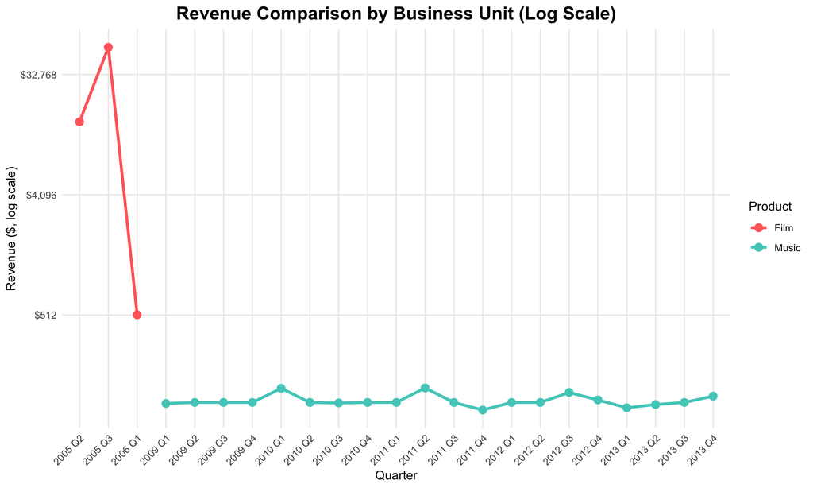

```r
# Get quarterly revenue data for chart
quarterly_data_sql <- "
  SELECT
    year,
    quarter,
    product_type,
    SUM(revenue) as revenue
  FROM fact_sales
  GROUP BY year, quarter, product_type
  ORDER BY year, quarter, product_type
"

quarterly_data <- dbGetQuery(con, quarterly_data_sql)

# Create quarter labels
quarterly_data$quarter_label <- paste0(quarterly_data$year, " Q", quarterly_data$quarter)

# Create the plot
ggplot(quarterly_data, aes(x = quarter_label, y = revenue, color = product_type, group = product_type)) +
  geom_line(size = 1.2) +
  geom_point(size = 3) +
  scale_y_continuous(trans = "log2", labels = scales::dollar_format()) +
  scale_color_manual(values = c("film" = "#FF6B6B", "music" = "#4ECDC4"),
                     labels = c("Film", "Music")) +
  labs(title = "Revenue Comparison by Business Unit (Log Scale)",
       x = "Quarter",
       y = "Revenue ($, log scale)",
       color = "Product") +
  theme_minimal() +
  theme(axis.text.x = element_text(angle = 45, hjust = 1),
        plot.title = element_text(size = 16, face = "bold", hjust = 0.5),
        legend.position = "right",
        panel.grid.minor = element_blank())
```

```r
# Get the three most recent years
recent_years_sql <- "SELECT DISTINCT year FROM fact_sales ORDER BY year DESC LIMIT 3"
recent_years <- sort(dbGetQuery(con, recent_years_sql)$year)

# Get units sold by country and quarter for recent years
units_sql <- paste0("
  SELECT
    country,
    quarter,
    year,
    SUM(units_sold) as units
  FROM fact_sales
  WHERE year IN (", paste(recent_years, collapse = ", "), ")
    AND country IN ('Canada', 'United States', 'Brazil')
  GROUP BY country, quarter, year
  ORDER BY country, year, quarter
")

units_data <- dbGetQuery(con, units_sql)

# Create formatted table for each country
create_country_table <- function(country_name, data, years) {
  country_data <- data[data$country == country_name, ]

  # Reshape data
  summary_table <- data.frame(
    Quarter = c("Q1", "Q2", "Q3", "Q4", "Total", "Average")
  )

  for (yr in years) {
    yr_data <- country_data[country_data$year == yr, ]
    if (nrow(yr_data) > 0) {
      q_values <- c(
        sum(yr_data$units[yr_data$quarter == 1]),
        sum(yr_data$units[yr_data$quarter == 2]),
        sum(yr_data$units[yr_data$quarter == 3]),
        sum(yr_data$units[yr_data$quarter == 4])
      )
      total <- sum(q_values)
      avg <- mean(q_values)
      summary_table[[as.character(yr)]] <- c(q_values, total, avg)
    } else {
      summary_table[[as.character(yr)]] <- c(0, 0, 0, 0, 0, 0)
    }
  }

  # Add total and average columns
  if (length(years) > 0) {
    summary_table$Total <- rowSums(summary_table[, 2:(length(years) + 1)])
    summary_table$Average <- round(rowMeans(summary_table[, 2:(length(years) + 1)]))
  }

  return(summary_table)
}
```

```r
# Get the three most recent years
recent_years_sql <- "SELECT DISTINCT year FROM fact_sales ORDER BY year DESC LIMIT 3"
recent_years <- sort(dbGetQuery(con, recent_years_sql)$year)

# Get units sold by country and quarter for recent years
units_sql <- paste0("
  SELECT
    country,
    quarter,
    year,
    SUM(units_sold) as units
  FROM fact_sales
  WHERE year IN (", paste(recent_years, collapse = ", "), ")
    AND country IN ('Canada', 'United States', 'Brazil')
  GROUP BY country, quarter, year
  ORDER BY country, year, quarter
")

units_data <- dbGetQuery(con, units_sql)

# Create a combined table for all countries
all_countries <- c("Canada", "United States", "Brazil")

# Initialize the results list
results_list <- list()

for (country in all_countries) {
  country_data <- units_data[units_data$country == country, ]

  # Add country header
  results_list[[length(results_list) + 1]] <- data.frame(
    col1 = paste0("**", ifelse(country == "United States", "USA", country), "**"),
    col2 = "", col3 = "", col4 = "", col5 = "", col6 = ""
  )

  # Add blank row
  results_list[[length(results_list) + 1]] <- data.frame(
    col1 = "", col2 = "", col3 = "", col4 = "", col5 = "", col6 = ""
  )

  # Add data rows for each quarter
  for (q in 1:4) {
    row_data <- data.frame(col1 = paste0("Q", q))

    for (yr in recent_years) {
      val <- country_data[country_data$year == yr & country_data$quarter == q, "units"]
      row_data[[paste0("col", which(recent_years == yr) + 1)]] <- ifelse(length(val) > 0, format(val, big.mark = ","), "0")
    }

    # Calculate total and average
    q_data <- country_data[country_data$quarter == q, "units"]
    total <- ifelse(length(q_data) > 0, sum(q_data), 0)
    avg <- ifelse(length(q_data) > 0, round(mean(q_data)), 0)

    row_data[["col5"]] <- format(total, big.mark = ",")
    row_data[["col6"]] <- format(avg, big.mark = ",")

    results_list[[length(results_list) + 1]] <- row_data
  }

  # Add Total row
  total_row <- data.frame(col1 = "Total")
  for (yr in recent_years) {
    yr_total <- sum(country_data[country_data$year == yr, "units"])
    total_row[[paste0("col", which(recent_years == yr) + 1)]] <- format(yr_total, big.mark = ",")
  }
  grand_total <- sum(country_data$units)
  total_row[["col5"]] <- format(grand_total, big.mark = ",")
  total_row[["col6"]] <- format(round(grand_total / length(recent_years)), big.mark = ",")
  results_list[[length(results_list) + 1]] <- total_row

  # Add Average row
  avg_row <- data.frame(col1 = "Average")
  for (yr in recent_years) {
    yr_data <- country_data[country_data$year == yr, "units"]
    yr_avg <- ifelse(length(yr_data) > 0, round(mean(yr_data)), 0)
    avg_row[[paste0("col", which(recent_years == yr) + 1)]] <- format(yr_avg, big.mark = ",")
  }
  overall_avg <- round(mean(country_data$units))
  avg_row[["col5"]] <- format(overall_avg * 4, big.mark = ",")  # Total of averages
  avg_row[["col6"]] <- format(overall_avg, big.mark = ",")
  results_list[[length(results_list) + 1]] <- avg_row

  # Add blank row between countries (except after last country)
  if (country != "Brazil") {
    results_list[[length(results_list) + 1]] <- data.frame(
      col1 = "", col2 = "", col3 = "", col4 = "", col5 = "", col6 = ""
    )
  }
}

# Combine all rows
combined_table <- do.call(rbind, results_list)
names(combined_table) <- c("", as.character(recent_years), "Total", "Average")

# Create the table with proper formatting
combined_table %>%
  kbl(align = c('l', rep('c', length(recent_years) + 2)),
      escape = FALSE) %>%
  kable_styling(bootstrap_options = c("striped", "hover"),
                full_width = FALSE,
                position = "left") %>%
  add_header_above(c(" " = 1, "Years" = length(recent_years), " " = 2)) %>%
  row_spec(c(7, 8, 15, 16, 23, 24), bold = TRUE, background = "#f0f0f0") %>%
  column_spec(1, width = "100px") %>%
  column_spec(2:(length(recent_years) + 3), width = "80px")
```

|  | Years 2011 | Years 2012 | Years 2013 | Total | Average |
| --- | --- | --- | --- | --- | --- |
| **Canada** |  |  |  |  |  |
| Q1 | 26 | 10 | 20 | 56 | 19 |
| Q2 | 6 | 26 | 22 | 54 | 18 |
| Q3 | 9 | 2 | 25 | 36 | 12 |
| Q4 | 15 | 5 | 6 | 26 | 9 |
| Total | 56 | 43 | 73 | 172 | 57 |
| Average | 14 | 11 | 18 | 56 | 14 |
| **USA** |  |  |  |  |  |
| Q1 | 12 | 18 | 14 | 44 | 15 |
| Q2 | 32 | 18 | 20 | 70 | 23 |
| Q3 | 29 | 38 | 20 | 87 | 29 |
| Q4 | 26 | 28 | 32 | 86 | 29 |
| Total | 99 | 102 | 86 | 287 | 96 |
| Average | 25 | 26 | 22 | 96 | 24 |
| **Brazil** |  |  |  |  |  |
| Q1 | 4 | 19 | 3 | 26 | 9 |
| Q2 | 7 | 4 | 0 | 11 | 6 |
| Q3 | 9 | 6 | 29 | 44 | 15 |
| Q4 | 0 | 25 | 6 | 31 | 16 |
| Total | 20 | 54 | 38 | 112 | 37 |
| Average | 7 | 14 | 13 | 44 | 11 |

# 3 Summary and Recommendations

```r
# Get key metrics for summary

years_film <- dbGetQuery(con, "SELECT MIN(year) as minYear, MAX(year) as maxYear FROM fact_sales WHERE product_type = 'film'")
years_music <- dbGetQuery(con, "SELECT MIN(year) as minYear, MAX(year) as maxYear FROM fact_sales WHERE product_type = 'music'")
total_revenue_max_year <- dbGetQuery(con, paste0("SELECT SUM(revenue) as total FROM fact_sales WHERE year = ", year_max$year[1]))$total
total_customers <- dbGetQuery(con, "SELECT COUNT(DISTINCT customer_key) as total FROM dim_customer")$total
total_countries <- dbGetQuery(con, "SELECT COUNT(DISTINCT country) as total FROM dim_customer")$total
```